### Is Solar Energy A Political Issue

### Introduction:

My research question is whether or not the solar output of each state can be dictated by political afiliation. This question pivoted from the original based on a poor representation of overal data. My initial question that I hoped to explore was whether headquarter location of top 10 (in valuation) american oil companies affected state wide solar output. The hiccup I ran into when exploring this was that over 70% of these companies had their headquarters in Texas. This lead to a poor dataset as there was a low representation in other states. After I realized this I pivoted my question to explore whether solar output state wide can see a correlation between positive output and political voting patterns. This is an interesting question because the idea of solar energy is one that is globaly impactful for all states and people, independent of political affiliation. Positive aspects include limited reliance on oil (and thus foreign policy implications as the US needs to send less soldiers to wars fought over dictating oil rich regions), climate change reduction (the fossil fuel emissions would be limited if cars, trains, planes and more were running off of solar power rather than currently harmful tendencies), fiscal advantages (government stipends for those who opt into a switch into renewable energy) and many more. I found interest in this question after deciding to work for a company over the summer who works towards using Artificial Inteligence to advance the output and profitability of solar fields. Once understanding this aspect of solar energy I began to wonder whether the aspects still holding us back could be political.

### Data:

Original Data Set: https://catalog.data.gov/dataset/energy-generation-by-state-and-technology-2009/resource/bb0da868-f498-4c47-b61f-da217897198f

My initial data was from a 2009 study of Energy Generation by Source and State alongside the results from the 2008 general election by state. I initially sliced this Energy Generation csv in order to solely include State and Solar output. This dataset includes all types of energy output (Coal, petrolium, solar, wind, etc) but I decided to limit this study to solely solar output. A thought I had for a later extension of this project would be to broaden the exploration and create a boolean variable for all renewable energy output. This would encompass states who have a positive renewable output that does not include solar, thus making our exploration more accurate. Once I had a set of States and Solar output, I pulled data of voting records and merged this into the current dataset by state name. Now my data includes State, Voting History, and Solar output. From here I did a variety of things to be used later including splitting into seperate Democratic and Republican sets, adding a boolean variable of Solar Positivity to the original set and adding a boolean variable of Republican to the original set.

### Exploratory data analysis:

```
## [1] "Democrat Positive Solar Output Percentage:  28.571429"
```

```
## [1] "Republican Positive Solar Output Percentage:  4.347826"
```

This shows the percentage of each political party affiliated state that has a positive solar output. 28.57% of the democratic states have a positive solar output and only 4.35% of the republican states have a positive solar output. This shows a large difference in output based on broken groups.

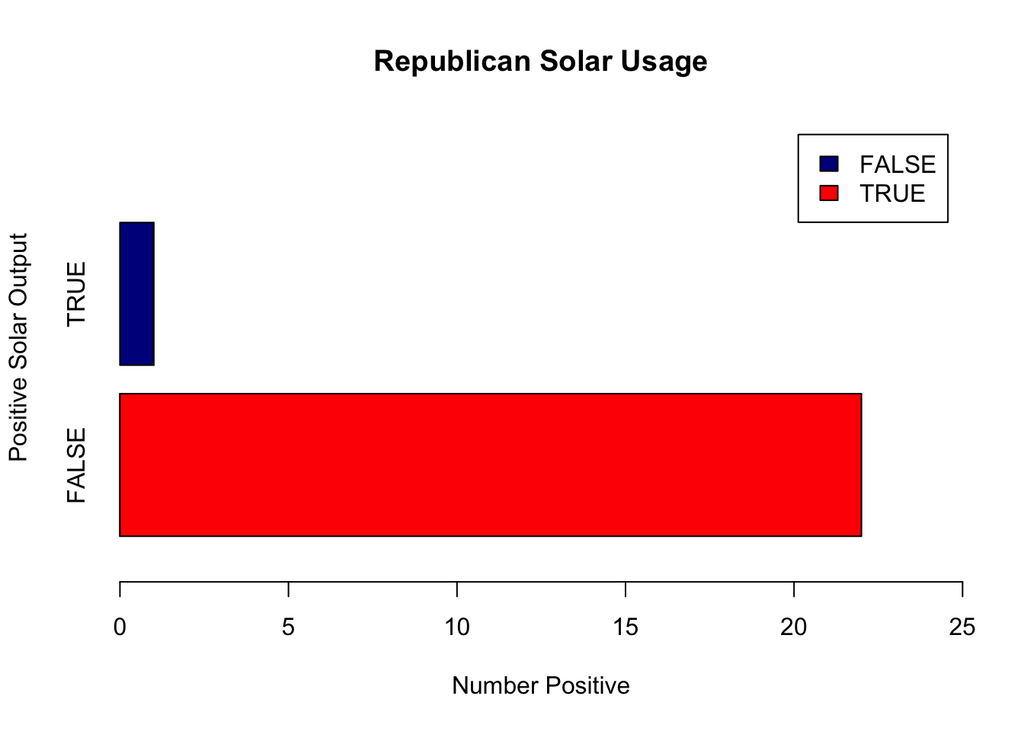

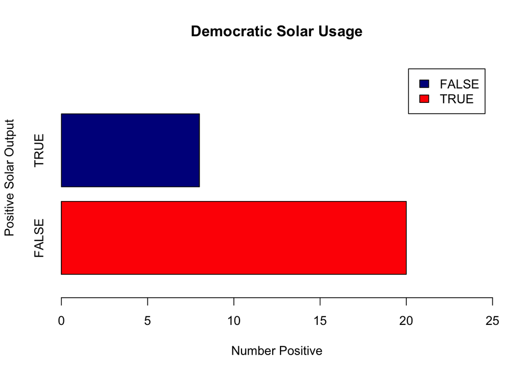

In these plots we see the republican portion alongisde the democratic portion on the same horizontal range. This allows us to see the difference in internal to party breakdowns of output. We can see that within each party, a higher portion of democratic states have a positive solar output when compared to that of republican states.

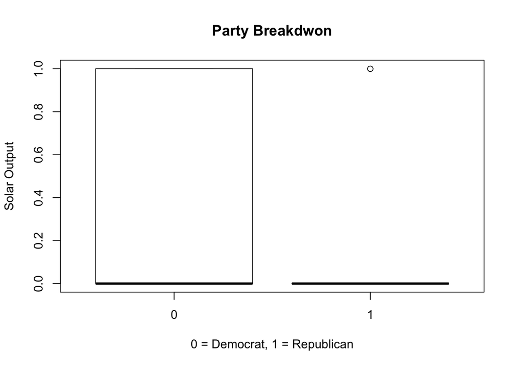

Although the above boxplot is not the prettiest representation it does share something important. As we know, in a box plot the lower quartile to the upper quartile (the box) show us a range of values that encompas the 25th to the 75th quartiles. Thus this includes the median as well as the middle 50% of values.  
In the boxplot shown above we can see that within the republican portion of this, this middle 50% and the bottom 25% (the bottom 75%) is all at the value 0. The maximum is shown at 1 which indicates that there are indeed republican states that have a positive solar output, but this also indicates that at least 75% of these republican states have no solar output.  
In the democrat boxplot, we see a median at 0, which means that less than 50% of the democrat states have positive solar output, but we see the upper quartile at 1. This indicates that more than 25% of democrat aligned states have a positive solar output.

```
## [1] "Condifence intervals: "
```

```
## [1] "Republican: 95 % Bootstrap interval = ( -0.0422 , 0.1331 )"
```

```
## [1] "Democrat: 95 % Bootstrap interval = ( 0.1195 , 0.4519 )"
```

Printing bootstrap confidence intervals because the knit is having an issue with it right now. Code works but is commented out because it will not convert to knit.  
In this interval we see something very important. In the republican 95% confidence bootstrap interval the confidence range has a negative minumum and includes 0 in the range. Clearly our data could not be negative considering they are boolean responses, but the fact that 0 is included is very important as it shows that we are confident that 0 is in the range of possible values.  
In the democrat data this is not the case, 0 is not in the range thus we are 95% confident that the response is not that there are 0 states with positive output. Although the range also does not include 1, the data not including 0 means that the distribution is high enough that the posibility on none containing positive solar output is not included.

```
##
##  Welch Two Sample t-test
##
## data:  statsData$SolarPositive by statsData$Republican
## t = 2.492, df = 39.186, p-value = 0.01704
## alternative hypothesis: true difference in means is not equal to 0
## 95 percent confidence interval:
##  0.04564886 0.43882319
## sample estimates:
## mean in group 0 mean in group 1
##      0.28571429      0.04347826
```

### Inference:

Goal: To simulate the Republican portion of the data (23 states) and use null and alternative probabilities and count the number of solar positive occurences.

```
##
##  Welch Two Sample t-test
##
## data:  newFrame$nullValsVec and newFrame$testValsVec
## t = 47.873, df = 1523.8, p-value < 2.2e-16
## alternative hypothesis: true difference in means is not equal to 0
## 95 percent confidence interval:
##  3.017098 3.274902
## sample estimates:
## mean of x mean of y
##     4.160     1.014
```